# EDA of Red Wine Quality Data

Now let’s see what the variables for sulfate and related compounds content looks like

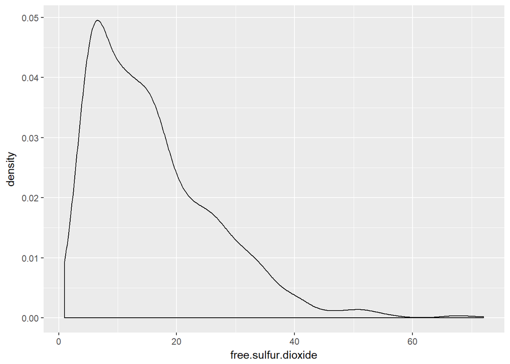

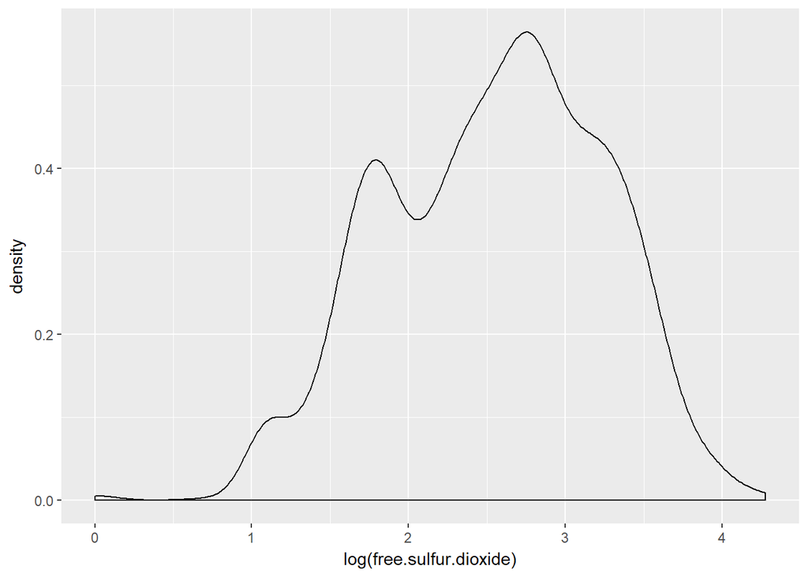

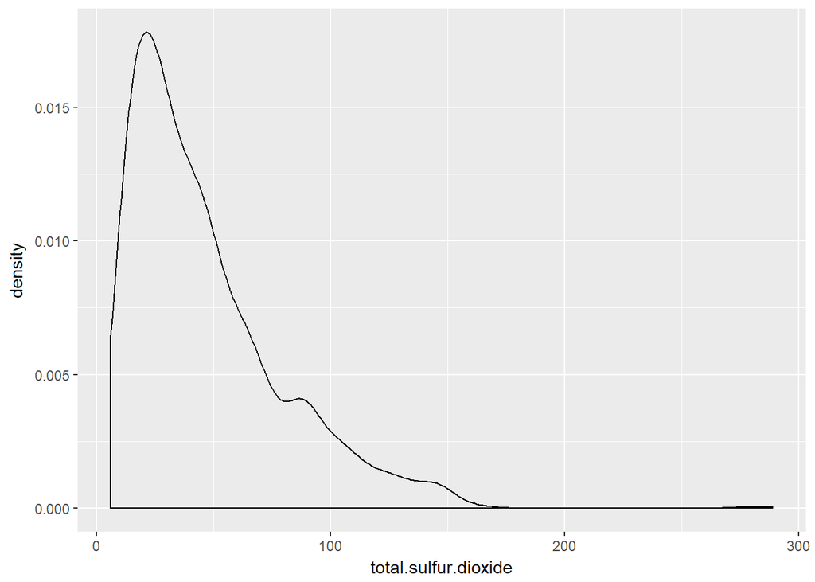

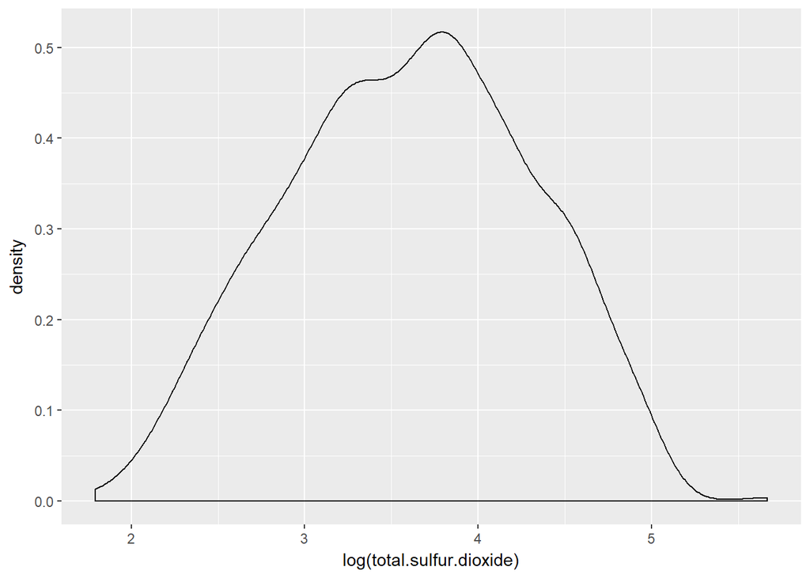

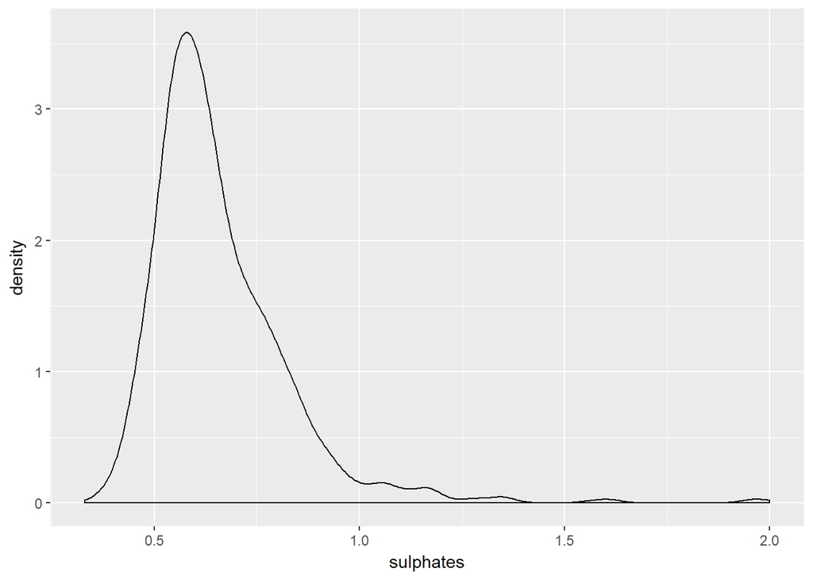

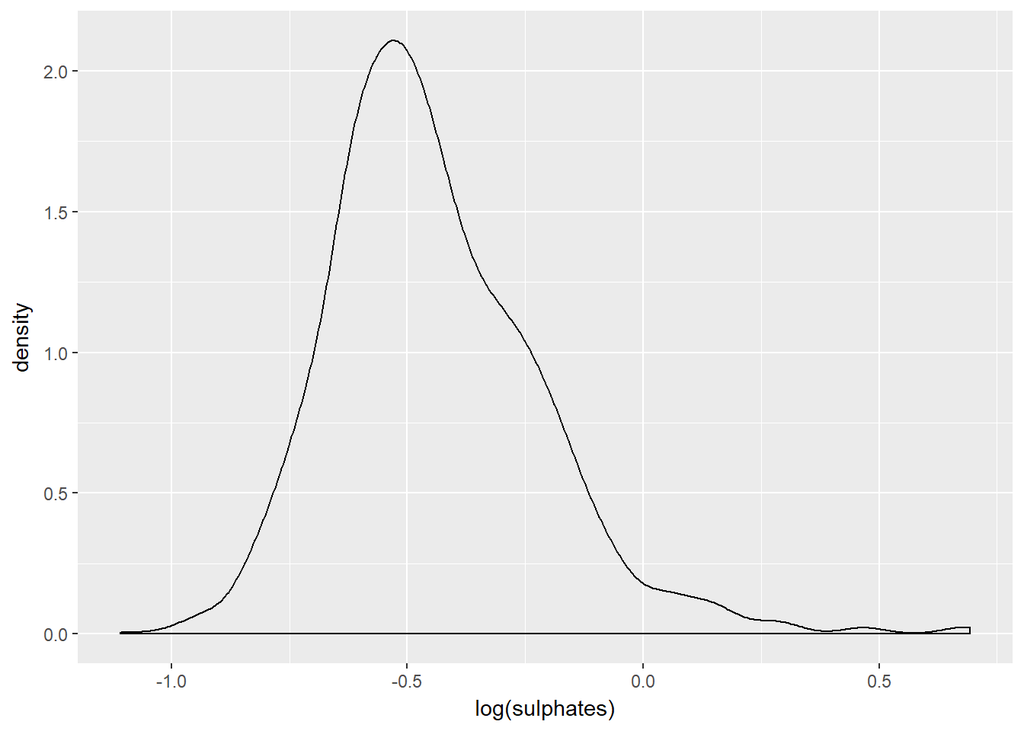

All of the sulfate variables seem to have a similar right skew. There seem to be some wines with very high sulfate content relative to the rest of the wines.

Finally let’s see what alcohol and related parameters looks like:

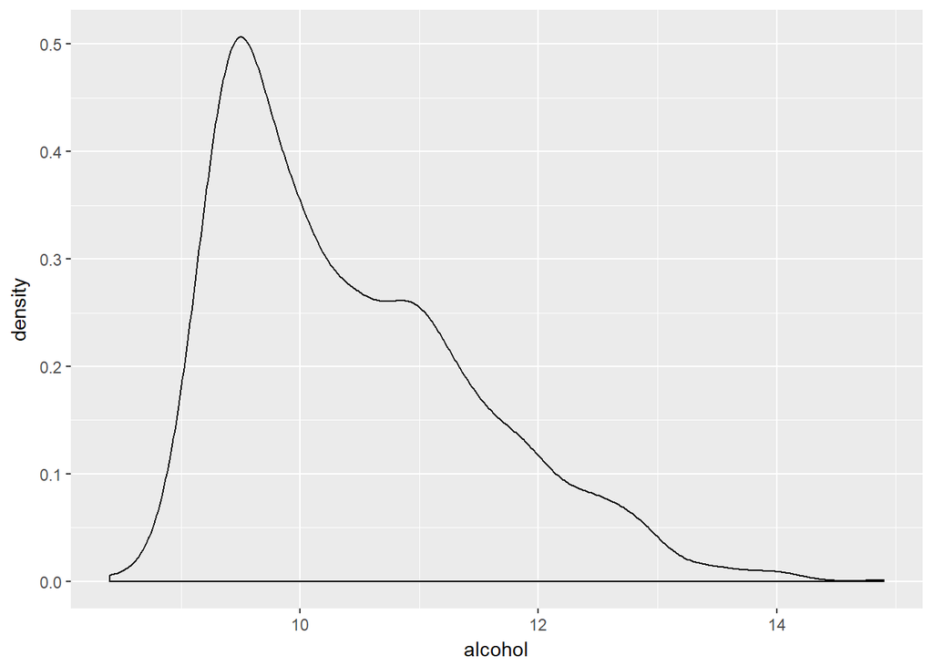

Most wines have between 9% and 11% ABV

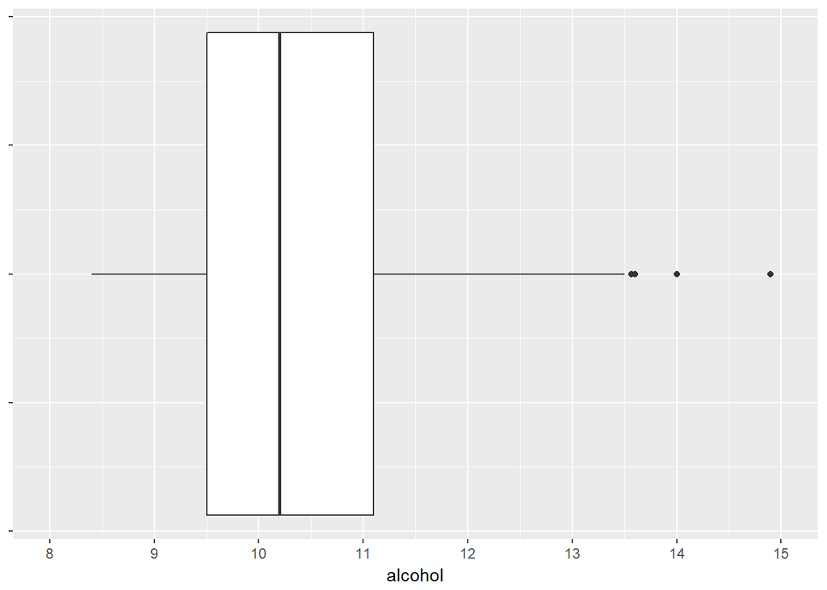

Half of the observations are between 9.5% to 11.1% ABV

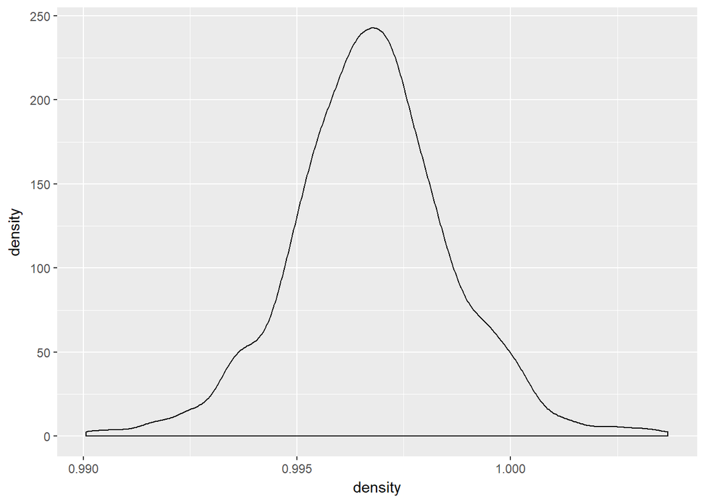

No surprises here.

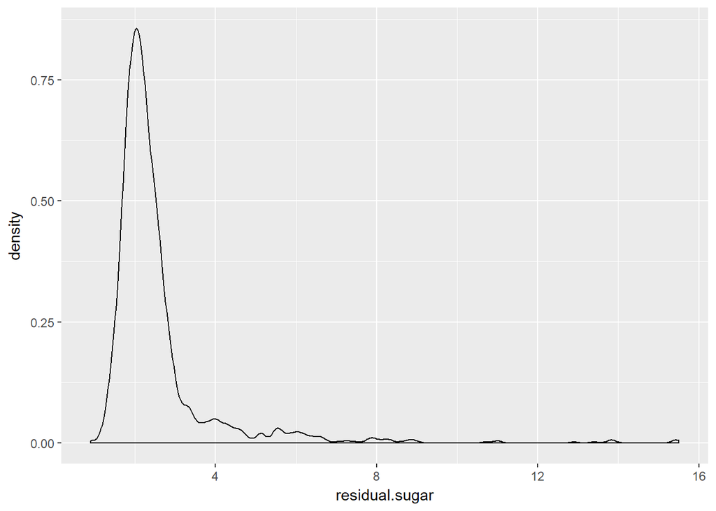

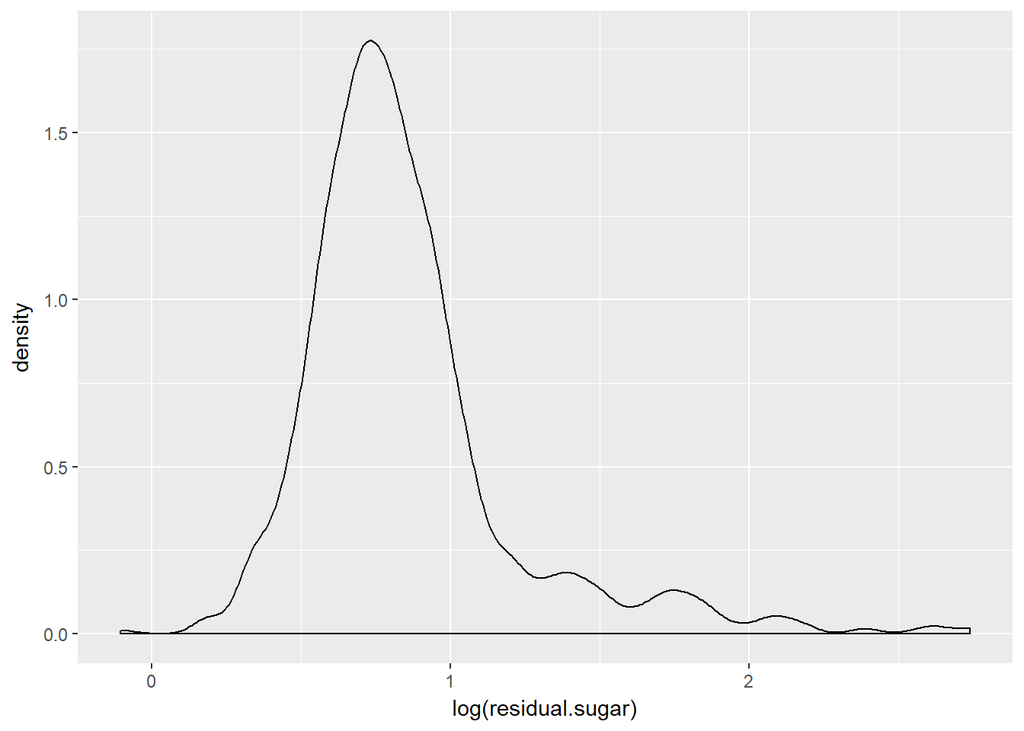

Most of the wines sampled have around 2 g/L residual.sugar. Plotting the log transformation of this variable indicates possible log-normal distribution of the variable.

There are some wines with very high residual sugars; let’s zoom in on the mean:

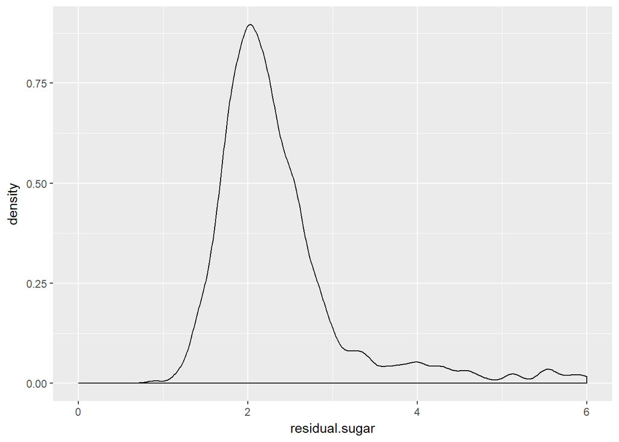

Seems like most of the values are between 1.5 and 2.5. There seems to be areas of increased frequency at 4 and 5 out on the tail.

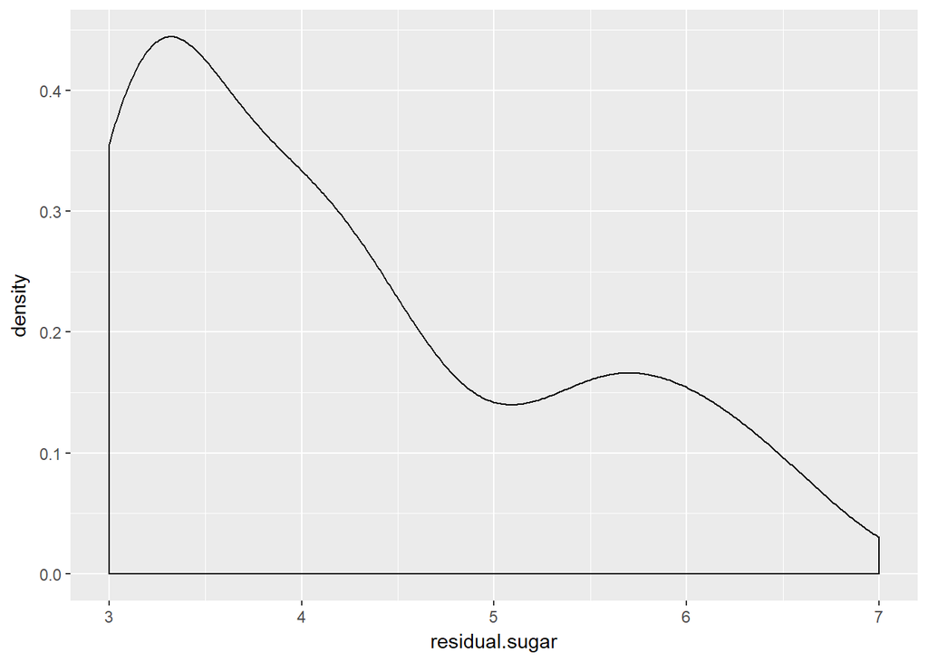

There seemed to be some secondary modes in the original plot, however I think all I was noticing places where there sparse values making it seem like an additional peak.

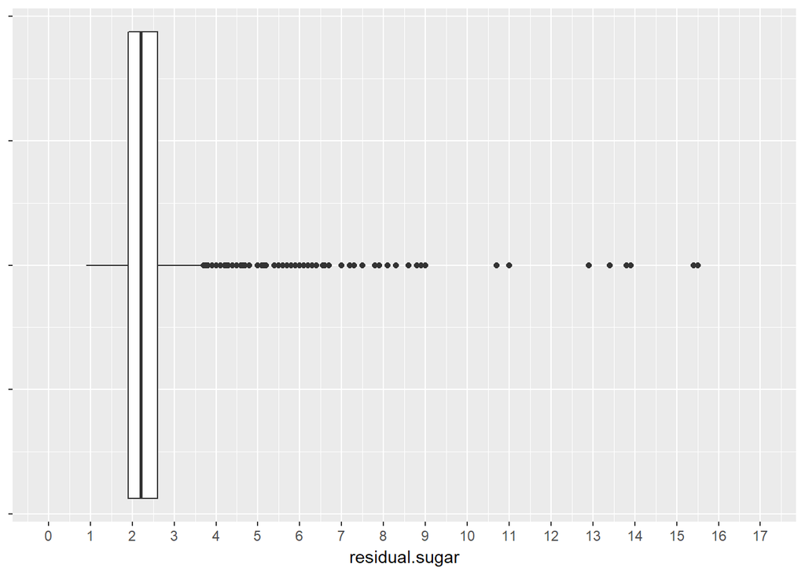

Box plot confirms what I was seeing in the density plot - most of the falling in a narrow lower band around the median with some widely spaced outliers.

Looks like most of the red wine sampled fell in the 9% to 11% ABV range. Alcohol volumes of 9.5% and 10.9% seem to more common. The plot of the density variable looks almost too perfectly normally distributed. It does make sense since there aren’t many wines with a very high alcohol content or very high residual sugars. I was expecting the alcohol and residual sugar plots to appear very similar. The relationship between these two variables must be more complex than I expected.

Last but not least - chlorides. This physio-chemical measurement didn’t fall in to any of the other logical groupings so it has been plotted on it’s own.

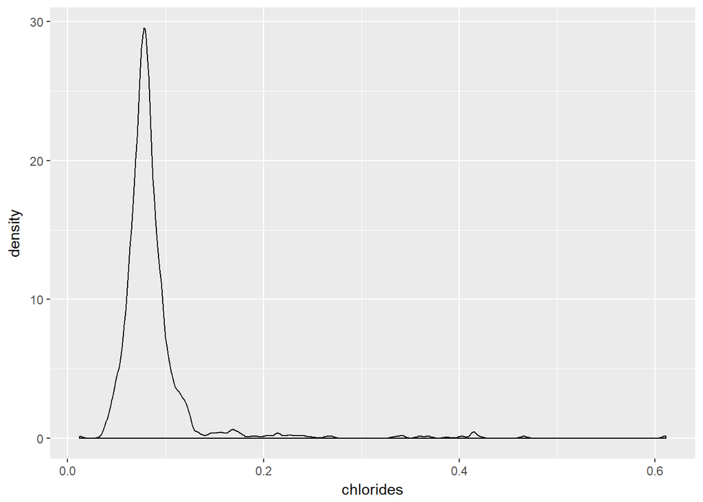

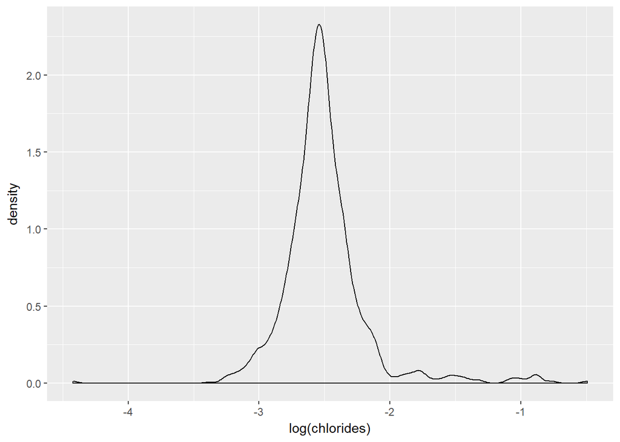

Very high right skew here possibly indicating a log-normal distribution. Plotting log transformed chlorides seems to confirm that. Very few observations outside of the 0.05 to 0.15 range.

# Univariate Analysis

### What is the structure of your dataset?

```r
str(wine_quality)
```

```
## 'data.frame':    1599 obs. of  13 variables:
##  $ X                   : int  1 2 3 4 5 6 7 8 9 10 ...
##  $ fixed.acidity       : num  7.4 7.8 7.8 11.2 7.4 7.4 7.9 7.3 7.8 7.5 ...
##  $ volatile.acidity    : num  0.7 0.88 0.76 0.28 0.7 0.66 0.6 0.65 0.58 0.5 ...
##  $ citric.acid         : num  0 0 0.04 0.56 0 0 0.06 0 0.02 0.36 ...
##  $ residual.sugar      : num  1.9 2.6 2.3 1.9 1.9 1.8 1.6 1.2 2 6.1 ...
##  $ chlorides           : num  0.076 0.098 0.092 0.075 0.076 0.075 0.069 0.065 0.073 0.071 ...
##  $ free.sulfur.dioxide : num  11 25 15 17 11 13 15 15 9 17 ...
##  $ total.sulfur.dioxide: num  34 67 54 60 34 40 59 21 18 102 ...
##  $ density             : num  0.998 0.997 0.997 0.998 0.998 ...
##  $ pH                  : num  3.51 3.2 3.26 3.16 3.51 3.51 3.3 3.39 3.36 3.35 ...
##  $ sulphates           : num  0.56 0.68 0.65 0.58 0.56 0.56 0.46 0.47 0.57 0.8 ...
##  $ alcohol             : num  9.4 9.8 9.8 9.8 9.4 9.4 9.4 10 9.5 10.5 ...
##  $ quality             : Ord.factor w/ 6 levels "3"<"4"<"5"<"6"<..: 3 3 3 4 3 3 3 5 5 3 ...
```

There are 1599 red wines in this data set each with measurements of 11 of their physio-chemical properties and a sensory measurement of quality. The quality variable is the median of at least 3 taste tests by wine experts. I have chosen to make quality and ordered factor to reflect the specification the researchers used when collecting these data - the higher the number, the better the wine.

### What is/are the main feature(s) of interest in your dataset?

The data set has several related groups of variables. With a view to predicting a quality rating one might consider the primary flavor or aromatic factors such as acidity (fixed.acidity, volatile.acidity, citric.acid) or sweetness (residual.sugars). The data set provides other measurements of interest. I am particularly interested in discovering if the group of variables for amounts of sulfur containing compounds (free.sulfur.dioxide, total.sulfur.dioxide, sulfates) has any effect on the quality score.

### What other features in the dataset do you think will help support your investigation into your feature(s) of interest?

I suspect that there might be multicolinearity in this data since often times the presence of higher acidity or sugars can alter ones perception of other compounds. I plan to investigate the how acidity and higher sugar content work in conjunction with the sulfur containing compound to effect the quality rating.

### Did you create any new variables from existing variables in the dataset?

Most of the variables in this data set seemed to be valuable on their own and there wasn’t any clear way to combine any of them in a meaningful way. One alteration I did make was to convert the quality variable in to a factor for easier analysis.

### Of the features you investigated, were there any unusual distributions? Did you perform any operations on the data to tidy, adjust, or change the form of the data? If so, why did you do this?

Some of the distributions were unexpected but not bizarre in any way.

# Bivariate Plots Section

What are the driving correlations?

```r
# https://briatte.github.io/ggcorr/
wq <- wine_quality[, !(names(wine_quality) %in% c("X"))]
wq$quality <- as.numeric(levels(wq$quality)[wq$quality])
wq.cor <- cor(wq)
data.frame(wq.cor)
```

```
##                      fixed.acidity volatile.acidity citric.acid
## fixed.acidity           1.00000000     -0.256130895  0.67170343
## volatile.acidity       -0.25613089      1.000000000 -0.55249568
## citric.acid             0.67170343     -0.552495685  1.00000000
## residual.sugar          0.11477672      0.001917882  0.14357716
## chlorides               0.09370519      0.061297772  0.20382291
## free.sulfur.dioxide    -0.15379419     -0.010503827 -0.06097813
## total.sulfur.dioxide   -0.11318144      0.076470005  0.03553302
## density                 0.66804729      0.022026232  0.36494718
## pH                     -0.68297819      0.234937294 -0.54190414
## sulphates               0.18300566     -0.260986685  0.31277004
## alcohol                -0.06166827     -0.202288027  0.10990325
## quality                 0.12405165     -0.390557780  0.22637251
##                      residual.sugar    chlorides free.sulfur.dioxide
## fixed.acidity           0.114776724  0.093705186        -0.153794193
## volatile.acidity        0.001917882  0.061297772        -0.010503827
## citric.acid             0.143577162  0.203822914        -0.060978129
## residual.sugar          1.000000000  0.055609535         0.187048995
## chlorides               0.055609535  1.000000000         0.005562147
## free.sulfur.dioxide     0.187048995  0.005562147         1.000000000
## total.sulfur.dioxide    0.203027882  0.047400468         0.667666450
## density                 0.355283371  0.200632327        -0.021945831
## pH                     -0.085652422 -0.265026131         0.070377499
## sulphates               0.005527121  0.371260481         0.051657572
## alcohol                 0.042075437 -0.221140545        -0.069408354
## quality                 0.013731637 -0.128906560        -0.050656057
##                      total.sulfur.dioxide     density          pH
## fixed.acidity                 -0.11318144  0.66804729 -0.68297819
## volatile.acidity               0.07647000  0.02202623  0.23493729
## citric.acid                    0.03553302  0.36494718 -0.54190414
## residual.sugar                 0.20302788  0.35528337 -0.08565242
## chlorides                      0.04740047  0.20063233 -0.26502613
## free.sulfur.dioxide            0.66766645 -0.02194583  0.07037750
## total.sulfur.dioxide           1.00000000  0.07126948 -0.06649456
## density                        0.07126948  1.00000000 -0.34169933
## pH                            -0.06649456 -0.34169933  1.00000000
## sulphates                      0.04294684  0.14850641 -0.19664760
## alcohol                       -0.20565394 -0.49617977  0.20563251
## quality                       -0.18510029 -0.17491923 -0.05773139
##                         sulphates     alcohol     quality
## fixed.acidity         0.183005664 -0.06166827  0.12405165
## volatile.acidity     -0.260986685 -0.20228803 -0.39055778
## citric.acid           0.312770044  0.10990325  0.22637251
## residual.sugar        0.005527121  0.04207544  0.01373164
## chlorides             0.371260481 -0.22114054 -0.12890656
## free.sulfur.dioxide   0.051657572 -0.06940835 -0.05065606
## total.sulfur.dioxide  0.042946836 -0.20565394 -0.18510029
## density               0.148506412 -0.49617977 -0.17491923
## pH                   -0.196647602  0.20563251 -0.05773139
## sulphates             1.000000000  0.09359475  0.25139708
## alcohol               0.093594750  1.00000000  0.47616632
## quality               0.251397079  0.47616632  1.00000000
```

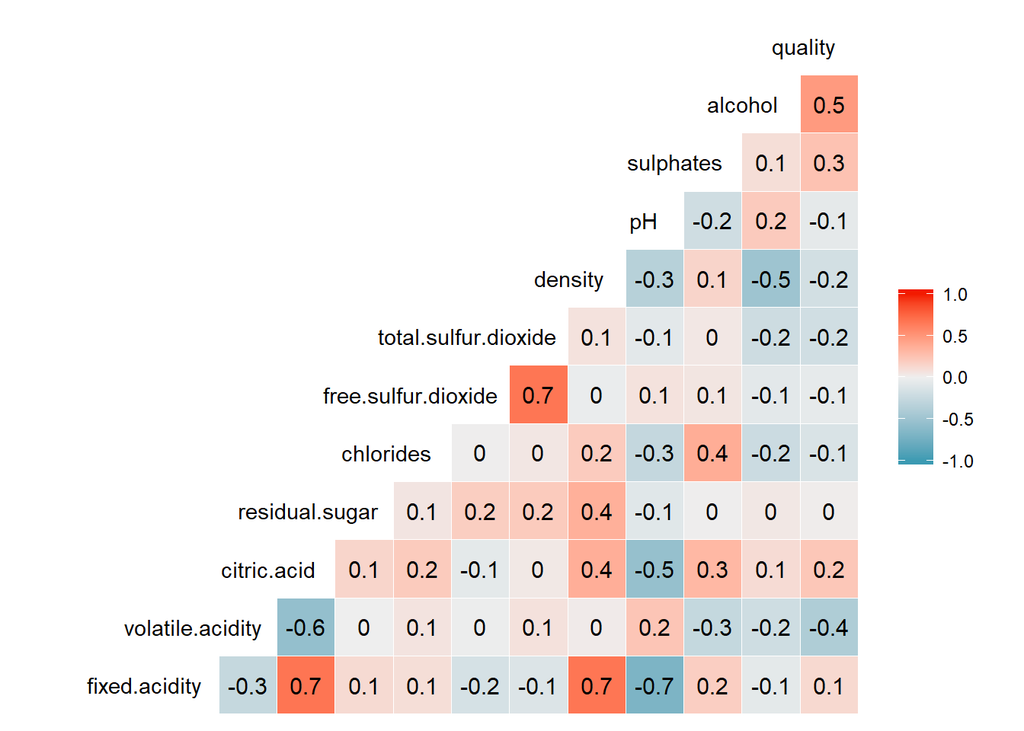

```r
# Using default continuous color map
ggcorr(wq, label = TRUE, hjust = 0.9, layout.exp = 2)
```

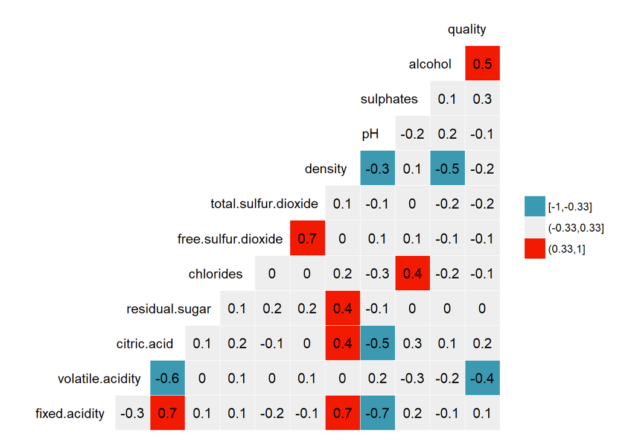

```r
# Using default descrete color map
ggcorr(wq, nbreaks = 3, label = TRUE, hjust = 0.9, layout.exp = 2)
```

Seeing this correlation plot I am curious if the taste testers were aware of the wine’s alcohol content during tasting. If so, I would be concerned that this is a source of bias in these data. The alcohol variable seems to explain about substantial amount of the variance in the quality variable. volatile.acidity has fairly high negative correlation to the quality variable. Not surprised about that. Acetic acid vapor is not what most people are looking for when they take the first sip. I am curious about the slightly elevated correlation of sulfates and the quality variable. Despite being evident during the uni-variate exploration, I am still a little surprised by the 0 values for residual.sugar for alcohol and quality.

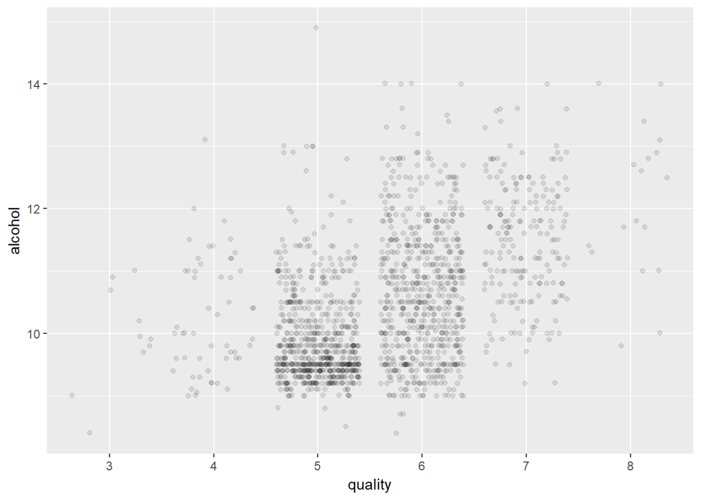

```r
ggplot(wine_quality, aes(x = quality, y = alcohol)) +
  geom_jitter(alpha = 1/10)
```

Tried several alpha values and jitter. There seems to be a lower mean when quality is 5 but a scatter plot with a factor makes things a little unclear. Probably better as box plot I am thinking.

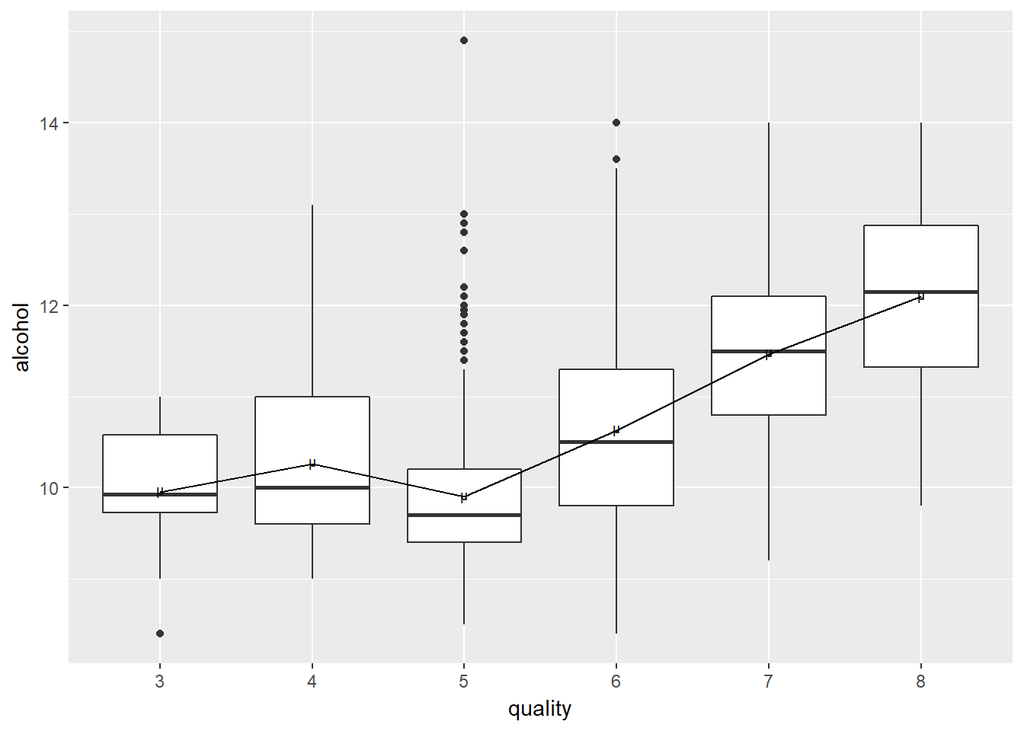

```r
# http://stackoverflow.com/questions/3989987/joining-means-on-a-boxplot-with-a-line-ggplot2
ggplot(wine_quality, aes(x = quality, y = alcohol)) +
  geom_boxplot() +
  # aes(group = 1) added to line plot forces stat_summary to be scoped to pre-aggregated data so line can connect means from each group
  stat_summary(aes(group = 1), fun.y = mean, geom = "line", show.legend = FALSE) +
  stat_summary(fun.y = mean, geom = "point", shape = "µ", size = 2, show.legend = FALSE)
```

That’s better. With the box plot you can the trend from the scatter plot more clearly. Most of the lower scores tend to have an alcohol content around 10. Scores of 5 are densely packed around the median with several outliers, some of which are extreme. Starting with scores of 6 and above there seems to be an upward trend in the mean alcohol content. To keep this in perspective I want to remind myself how many observations fall in to each of the scores. Adding the mean marker m and a connecting line makes the tendency in these data clearer.

```r
summary(wine_quality$quality)
```

```
##   3   4   5   6   7   8
##  10  53 681 638 199  18
```

Seeing that this trend presents itself over more than half of the observations is some additional supporting evidence to the correlation score alcohol and quality have.

Now for the next variable that has a higher correlation to quality, volatile.acidity

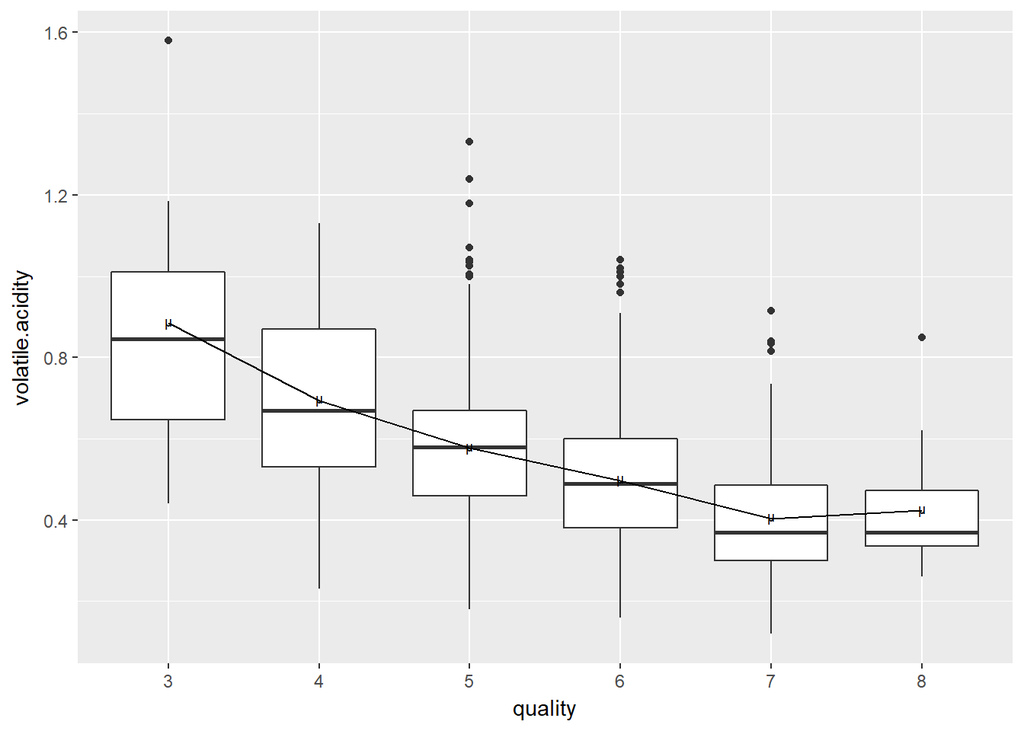

```r
# http://stackoverflow.com/questions/3989987/joining-means-on-a-boxplot-with-a-line-ggplot2
ggplot(wine_quality, aes(x = quality, y = volatile.acidity)) +
  geom_boxplot() +
  # aes(group = 1) added to line plot forces stat_summary to be scoped to pre-aggregated data so line can connect means from each group
  stat_summary(aes(group = 1), fun.y = mean, geom = "line", show.legend = FALSE) +
  stat_summary(fun.y = mean, geom = "point", shape = "µ", size = 2, show.legend = FALSE)
```

We can see the the negative correlation clearly here. The IQR is compressing as the quality improves. There is an overall negative trend in volatile.acidity as the quality increases.

Even though the effect of sulfates on quality doesn’t rank as highly as some of the other variables, I still want to examine it.

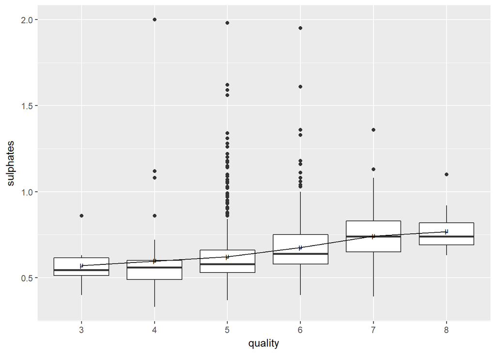

```r
# http://stackoverflow.com/questions/3989987/joining-means-on-a-boxplot-with-a-line-ggplot2
ggplot(wine_quality, aes(x = quality, y = sulphates)) +
  geom_boxplot() +
  # aes(group = 1) added to line plot forces stat_summary to be scoped to pre-aggregated data so line can connect means from each group
  stat_summary(aes(group = 1), fun.y = mean, geom = "line", show.legend = FALSE) +
  stat_summary(fun.y = mean, geom = "point", shape = "µ", size = 2, show.legend = FALSE)
```

It would seem that the wines that received a higher score tend to have higher sulfate levels.

The next interesting correlation from the initial correlation plot I want to examine is sulfates by chlorides.

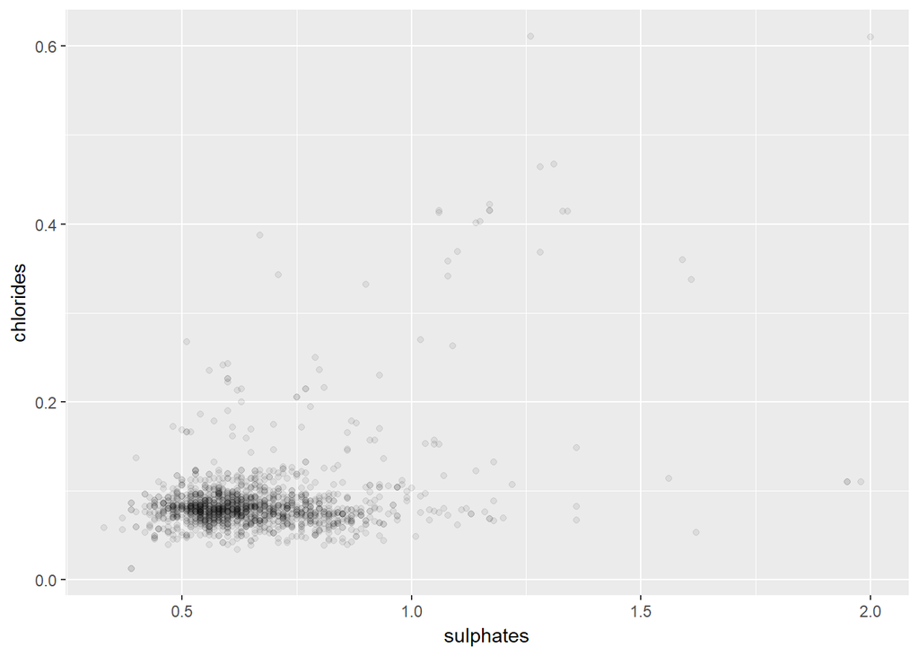

```r
ggplot(wine_quality, aes(x = sulphates, y = chlorides)) +
  geom_point(alpha = 1/15)
```

For the majority of the wines sampled the amount of chlorides is fairly consistent except of a few moderate and extreme cases. Sames goes for sulfates except for having the bulk of the values over a slightly larger range. There are observations where the sulfate measurement is high and the corresponding chloride measurement is low or high. There are no observations where the sulfate measurement is low and the chloride measurement is extreme. I don’t think this is a very meaningful correlation.